Loan Data from Prosper Last updated 03/11/2014

# Introduction

Prosper is America’s first marketplace lending platform, with over $10 billion in funded loans.Prosper allows people to invest in each other in a way that is financially and socially rewarding.This data set contains 113,937 loans with 81 variables on each loan, including, borrower rate , loan amount, loan status, borrower income, borrower employment status,ProsperScore, Loan Current Days Delinquent and other details.

========================================================

# Univariate Plots Section

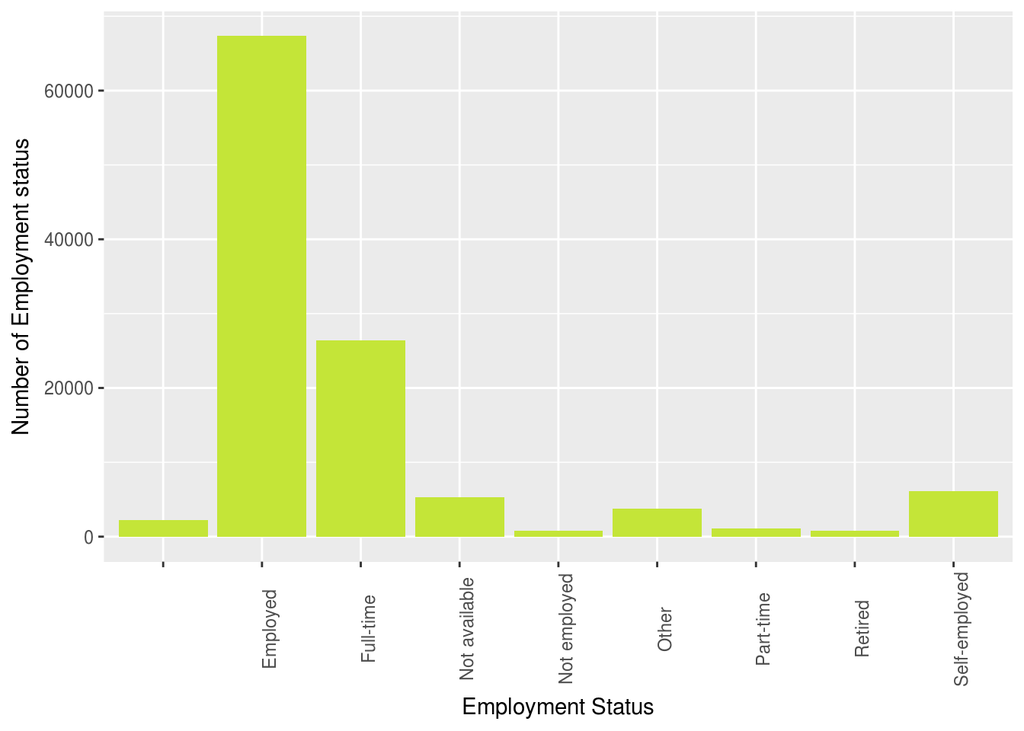

```
##                    Employed     Full-time Not available  Not employed
##          2255         67322         26355          5347           835
##         Other     Part-time       Retired Self-employed
##          3806          1088           795          6134
```

we notice that the employed category has the best opportunity of loan unlike unemployed

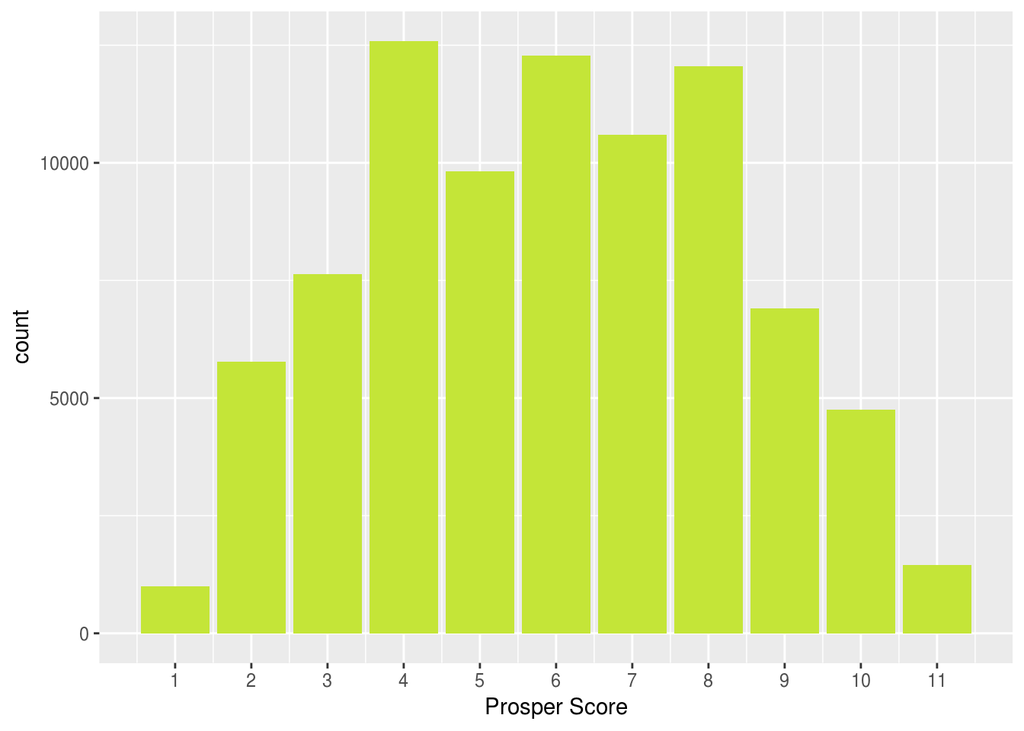

```
##    Min. 1st Qu.  Median    Mean 3rd Qu.    Max.    NA's
##    1.00    4.00    6.00    5.95    8.00   11.00   29084
```

This is plot shows that it is normally distributed and the mean of prosper score =5.95

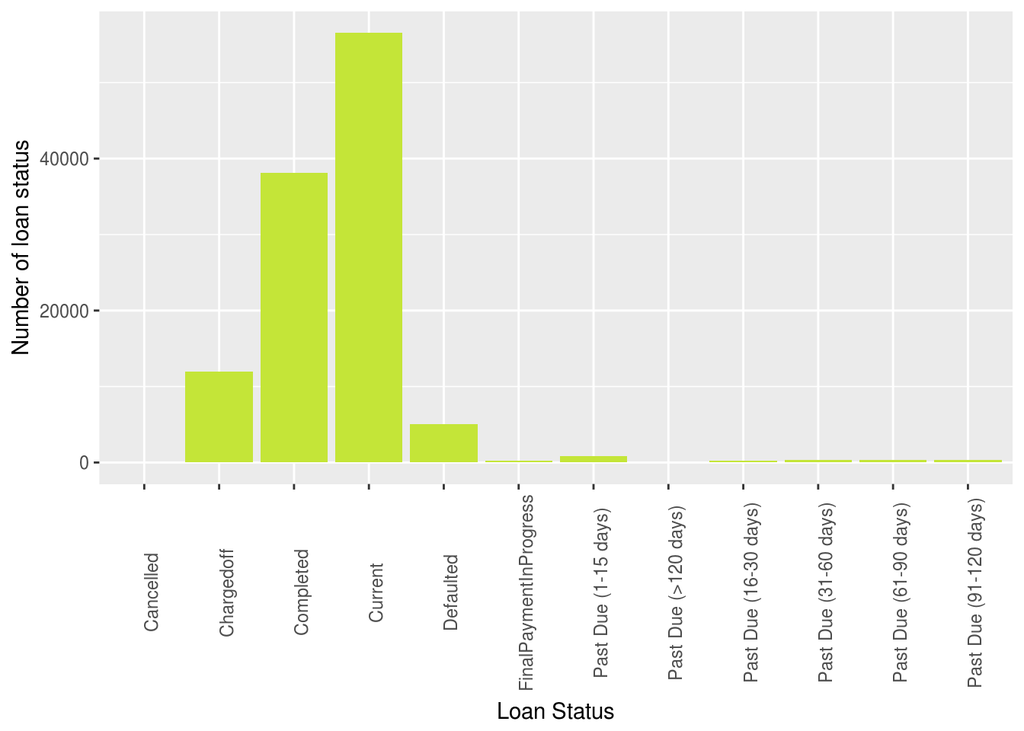

```
##              Cancelled             Chargedoff              Completed
##                      5                  11992                  38074
##                Current              Defaulted FinalPaymentInProgress
##                  56576                   5018                    205
##   Past Due (1-15 days)   Past Due (>120 days)  Past Due (16-30 days)
##                    806                     16                    265
##  Past Due (31-60 days)  Past Due (61-90 days) Past Due (91-120 days)
##                    363                    313                    304
```

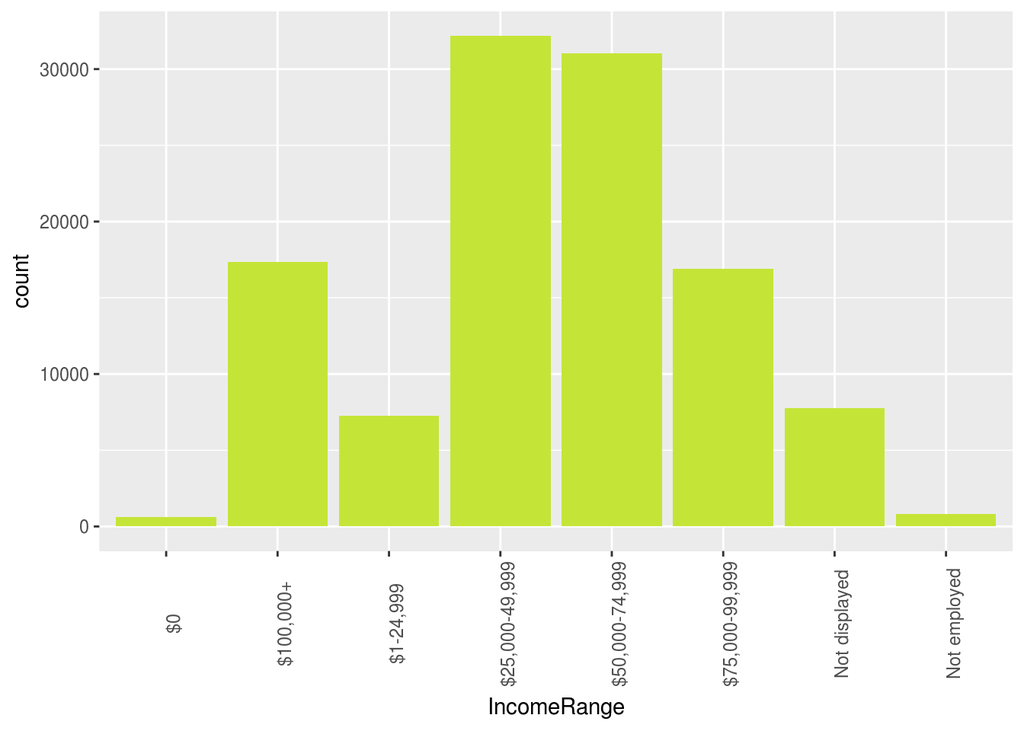

```
## $x
## [1] "Income Range"
##
## attr(,"class")
## [1] "labels"
```

```
##             $0      $100,000+      $1-24,999 $25,000-49,999 $50,000-74,999
##            621          17337           7274          32192          31050
## $75,000-99,999  Not displayed   Not employed
##          16916           7741            806
```

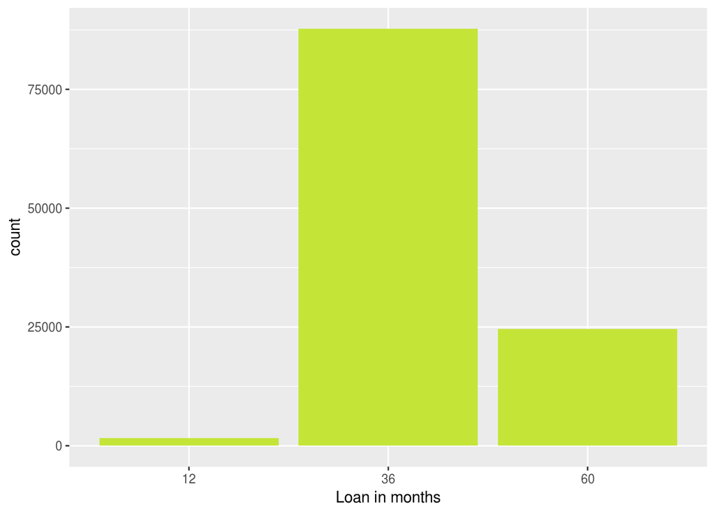

```
##    Min. 1st Qu.  Median    Mean 3rd Qu.    Max.
##   12.00   36.00   36.00   40.83   36.00   60.00
```

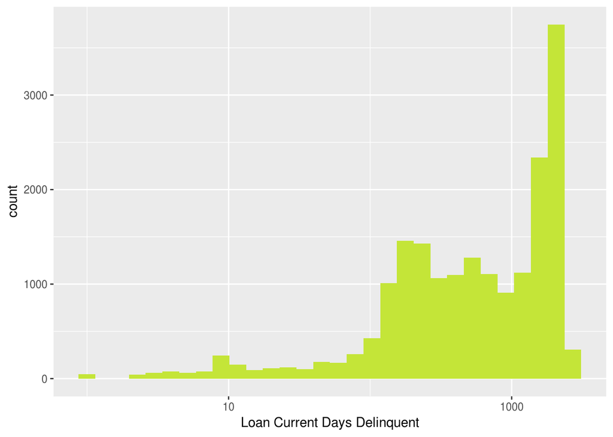

```
##    Min. 1st Qu.  Median    Mean 3rd Qu.    Max.
##     0.0     0.0     0.0   152.8     0.0  2704.0
```

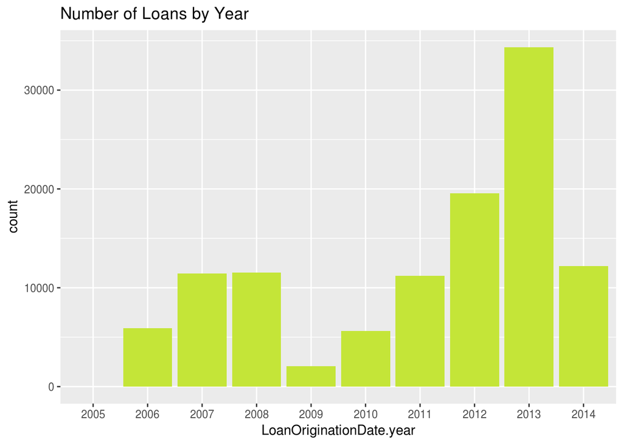

the biggest amount of loans was in 2013

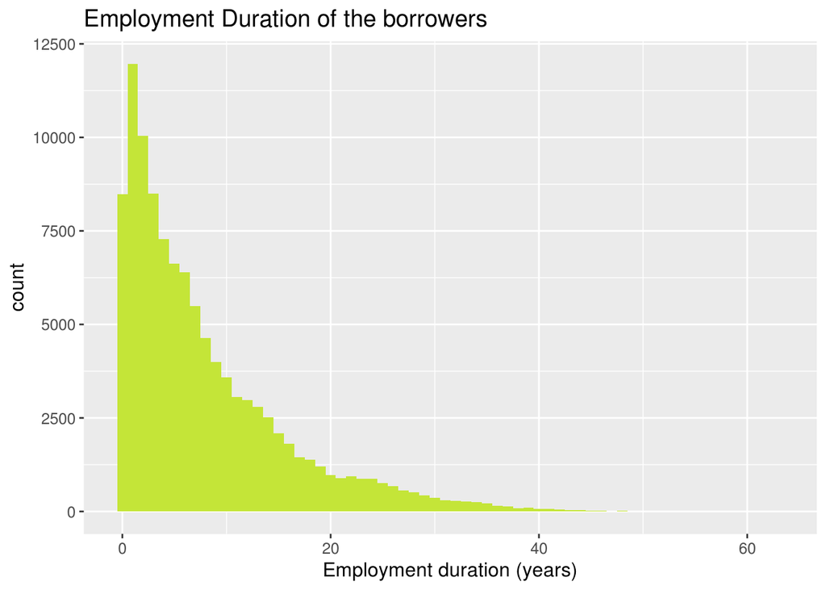

By increasing the durations of the work, the loan will be decreased

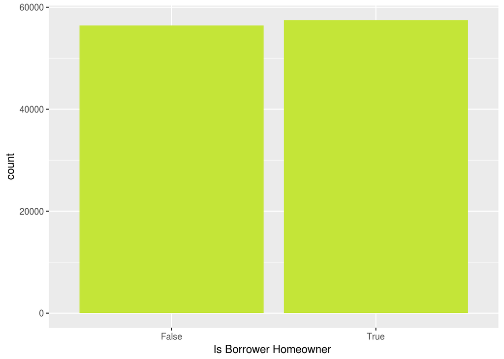

```
## False  True
## 56459 57478
```

The number of people who own houses almost equal The number of people who don’t own houses

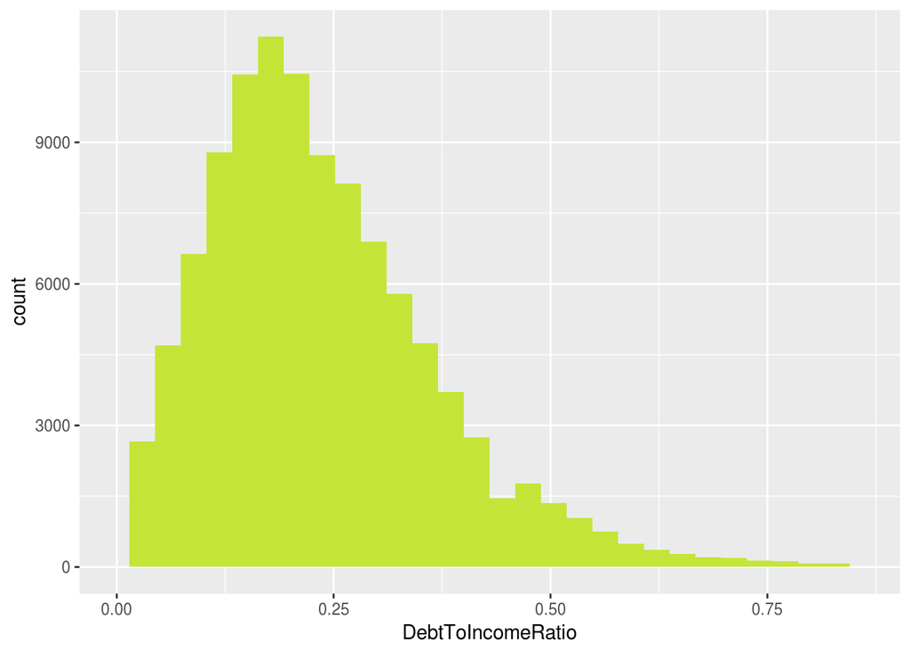

```
##    Min. 1st Qu.  Median    Mean 3rd Qu.    Max.    NA's
##   0.000   0.140   0.220   0.276   0.320  10.010    8554
```

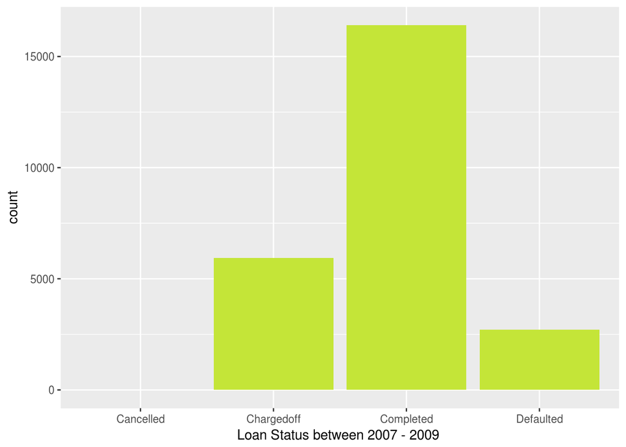

# Univariate Analysis

### What is the structure of your dataset?

This is dataset contains 113937 loans and 81 variables for Prosper Marketplace

### What is/are the main feature(s) of interest in your dataset?

#### - Income range

#### - employment Status

#### - loan Status

#### - ProsperScore

#### - Term

#### - Loan Current Days Delinquent

#### - Is Borrower Homeowner

#### - Borrower Rate

#### - Loan Year

### What other features in the dataset do you think will help support your investigation into your feature(s) of interest?

#### - occuption

#### - Employment Duration

#### - DelinquenciesInLast7Years

#### - BankCard Utilization

### Did you create any new variables from existing variables in the dataset?

-LoanOriginationDate.year => to define the year of the loan

### Of the features you investigated, were there any unusual distributions? Did you perform any operations on the data to tidy, adjust, or change the form of the data? If so, why did you do this?

-Outliers handling for Loan Current Days Delinquent by log-scaling (scale_x_log10())

# Bivariate Plots Section

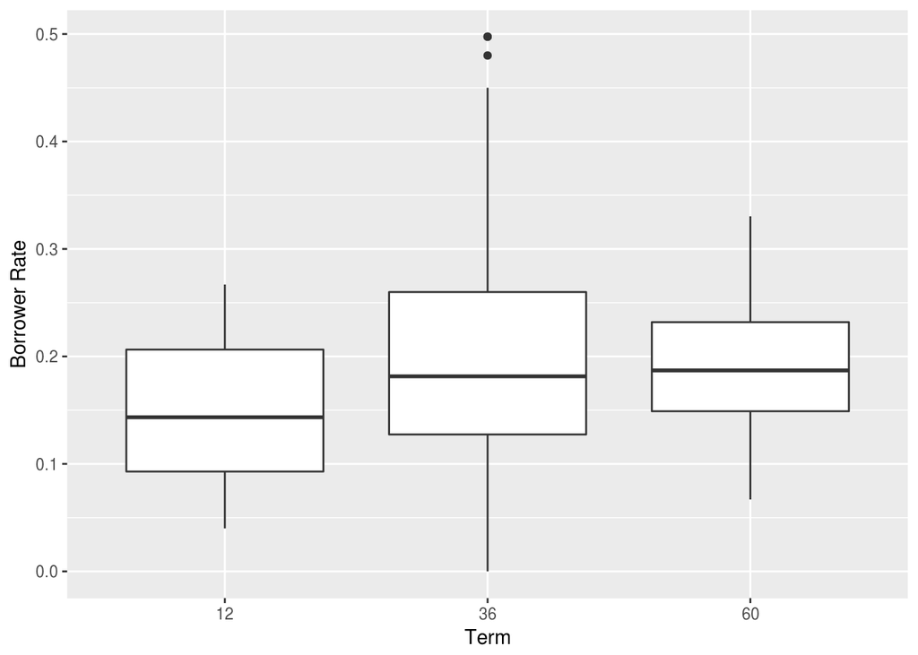

```
##
##  Pearson's product-moment correlation
##
## data:  loan_data$Term.months and loan_data$BorrowerRate
## t = 6.781, df = 113940, p-value = 1.199e-11
## alternative hypothesis: true correlation is not equal to 0
## 95 percent confidence interval:
##  0.01428050 0.02588888
## sample estimates:
##        cor
## 0.02008537
```

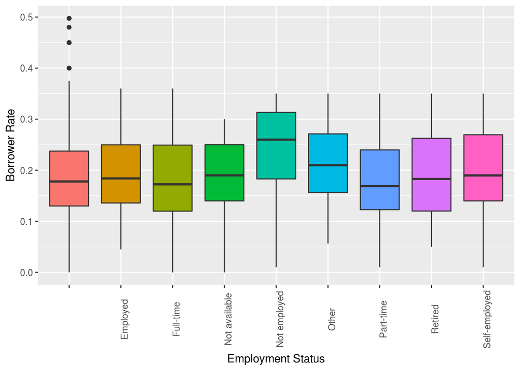

the unemploymed status has the higher borrower rate

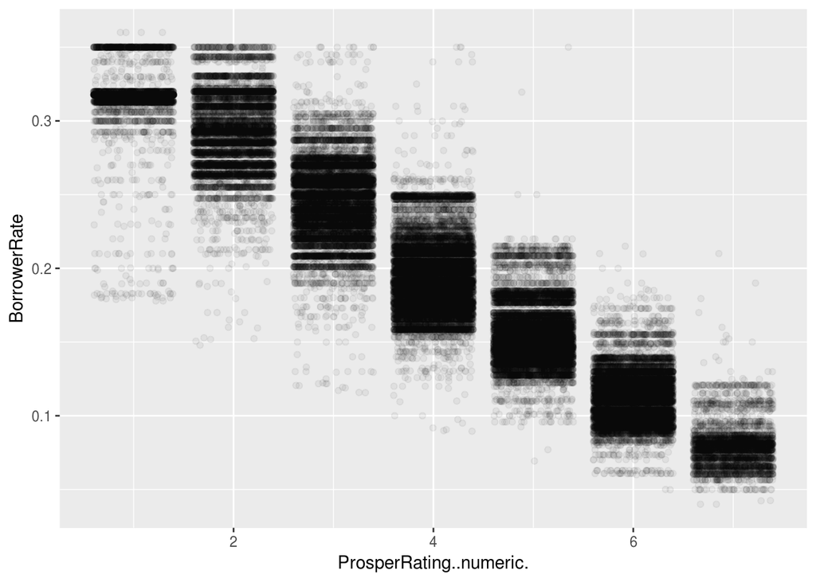

```
##
##  Pearson's product-moment correlation
##
## data:  ProsperRating..numeric. and BorrowerRate
## t = -854.52, df = 75587, p-value < 2.2e-16
## alternative hypothesis: true correlation is not equal to 0
## 95 percent confidence interval:
##  -0.9526073 -0.9512698
## sample estimates:
##        cor
## -0.9519431
```

we notice that the loans with higher interest rate are much more common in loans with higher risk (smaller scores)

-There is a strong negative relationship between Prosper Rating and interest rate

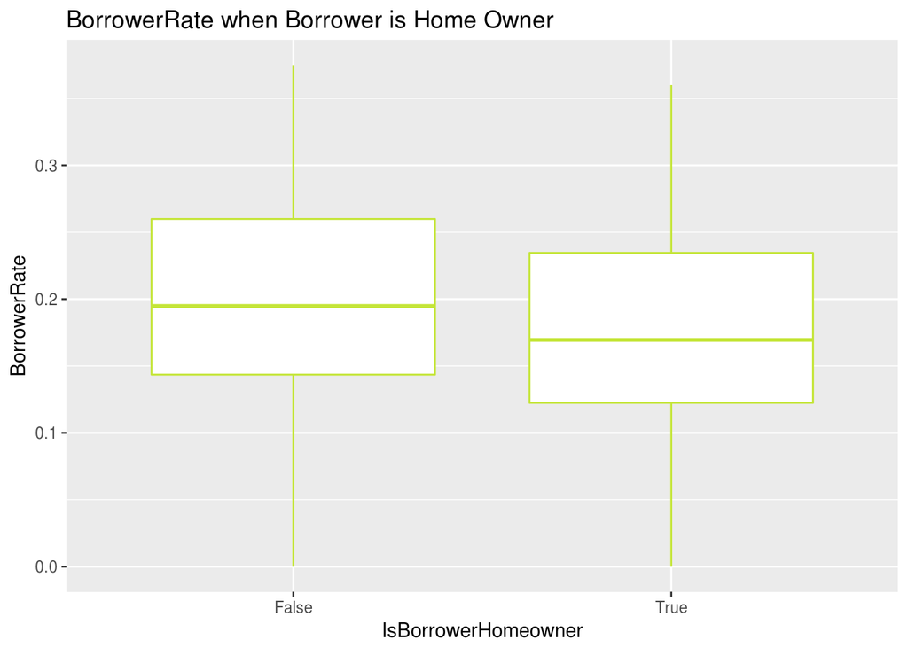

[output not shown]

if the borrower has a home ,the interest rate will be decreased

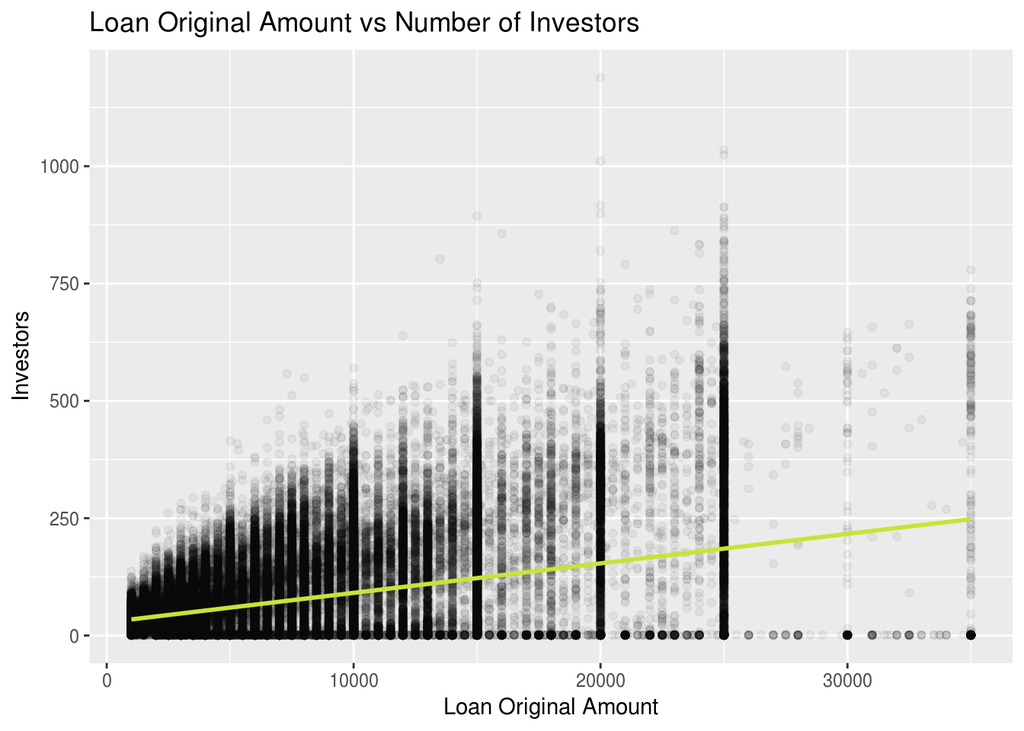

if the inverstors increase, the amount of loan will increase

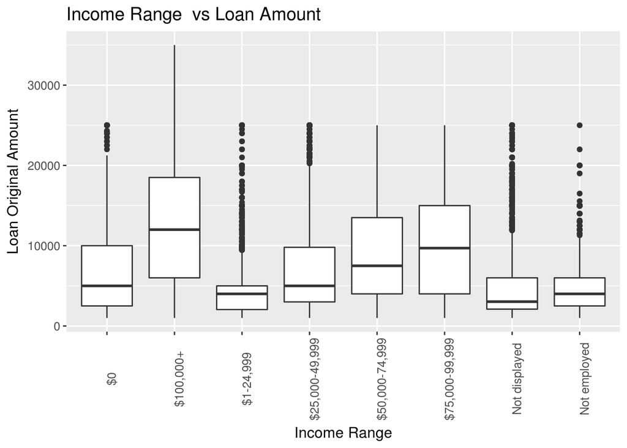

larger incomes on average Larger loans.

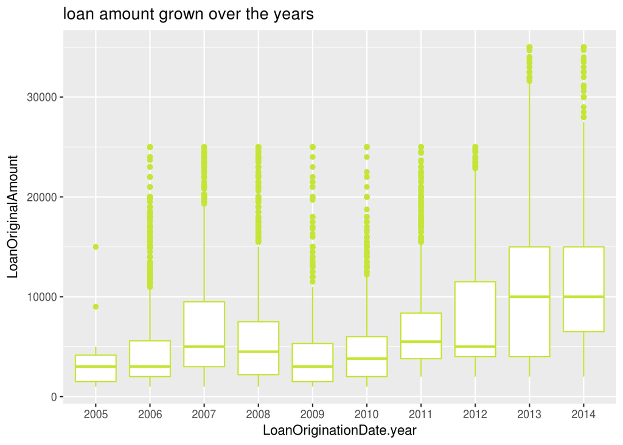

loan amount grown over the years particularlly from 2009 to 2014

# Bivariate Analysis

### Talk about some of the relationships you observed in this part of the investigation. How did the feature(s) of interest vary with other features in the dataset?

- larger incomes on average Larger loans.
- loan amount grown over the years particularlly from 2009 to 2014
- if the inverstors increase, the amount of loan will increase

### Did you observe any interesting relationships between the other features (not the main feature(s) of interest)?

- By increasing the durations of the work, the loan will be decreased

### What was the strongest relationship you found?

# Multivariate Analysis

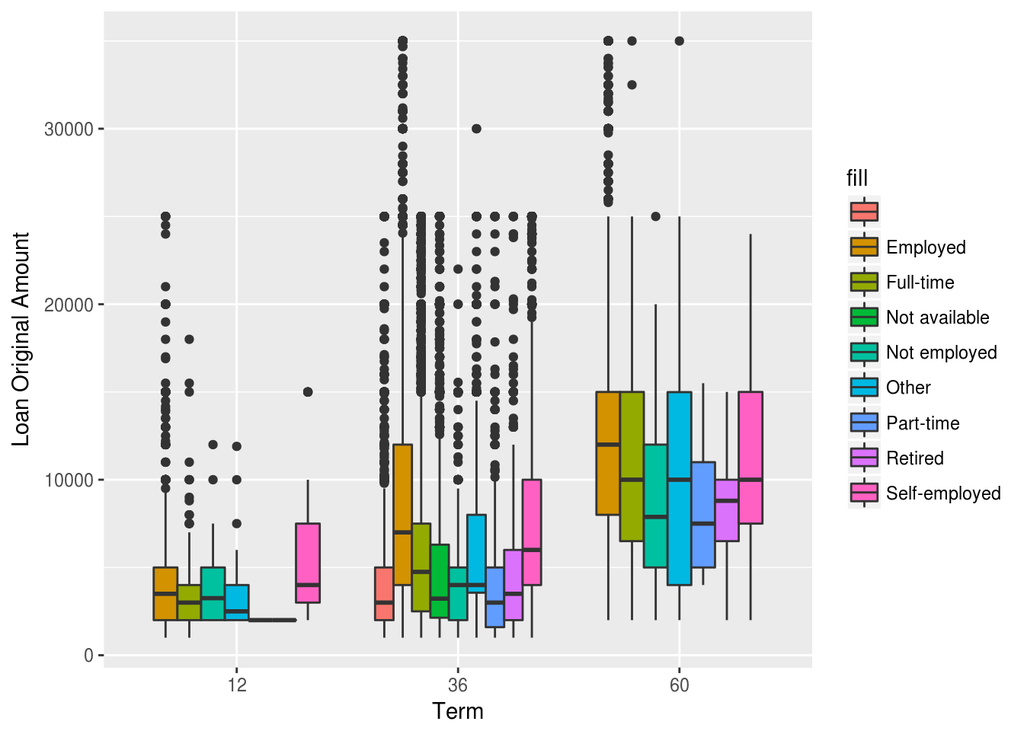

```
##
##  Pearson's product-moment correlation
##
## data:  loan_data$Term.months and loan_data$LoanOriginalAmount
## t = 121.6, df = 113940, p-value < 2.2e-16
## alternative hypothesis: true correlation is not equal to 0
## 95 percent confidence interval:
##  0.3337778 0.3440569
## sample estimates:
##       cor
## 0.3389275
```

- When the period is increased the amount of loan is increased
- The correlation coefficie indicate a moderate positive linear relationship between amount of loan and period.

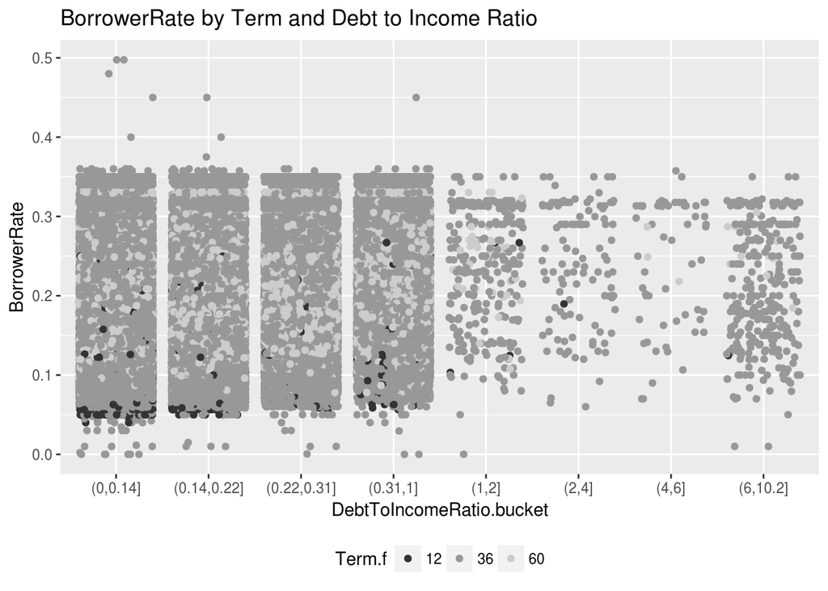

### Were there any interesting or surprising interactions between features?

- In general there is no surprises

# Final Plots and Summary

### Plot One

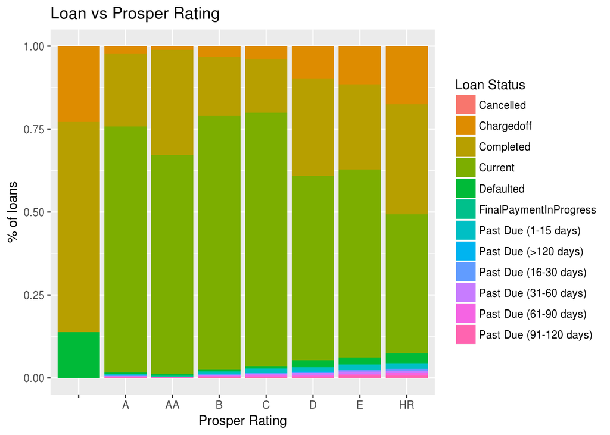

### Plot Two

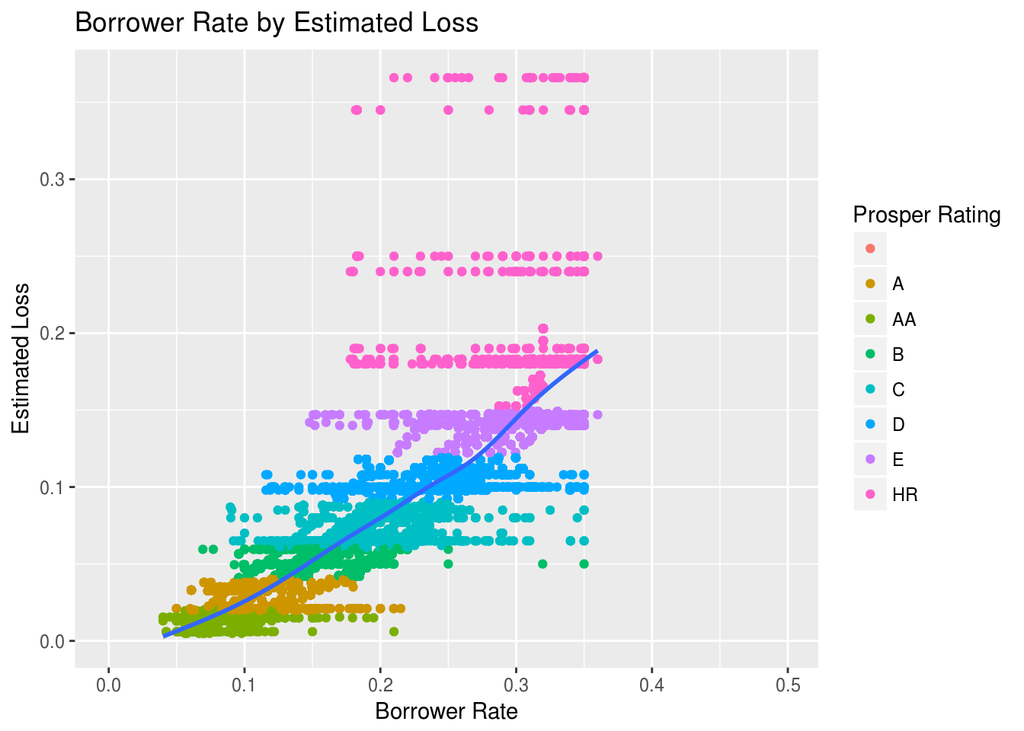

### Description Two

the borrower rate increasing with esimated loss and higher risk loans. While the Borrower Rate increases for loans considered to be higher risk

### Plot Three

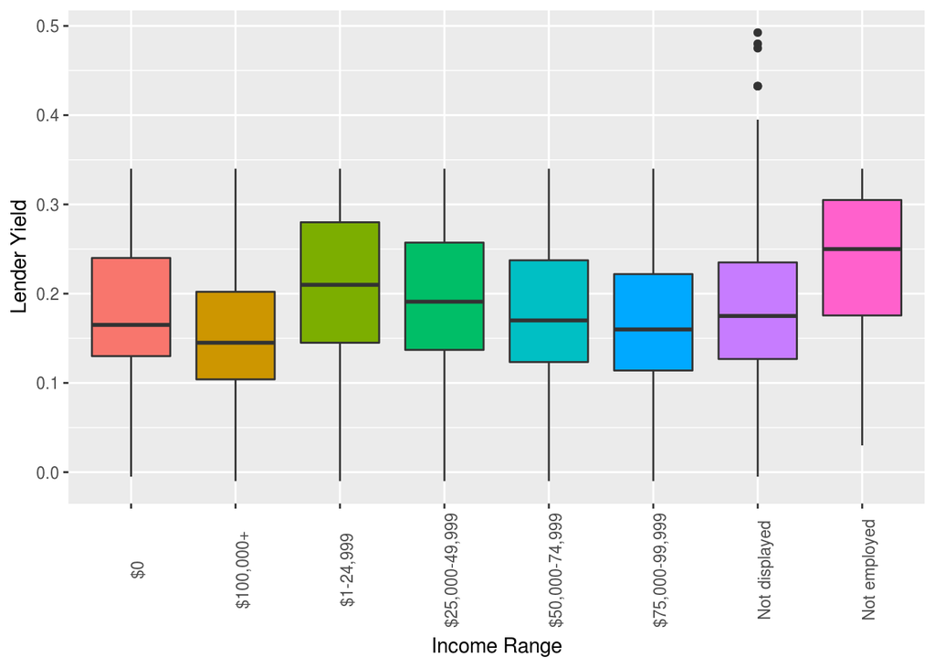

### Description Three

# Reflection

I selected the loan data to test my understanding of the course because it is bigger than the other datasets. I face some problems like dealing with outlires and ggplot syntax, but with the course materials and google, all problems are solved. Finally, I am trying to make a predictive models, such as a logistic regression for loan origination amount, Income Range,Loan Current Days Delinquent and Prosper score.